# Hydroloom

Weaving hydrologic geospatial fabrics with graph data structures

David Blodgett · U.S. Geological Survey

2026-05-19

## A fabric of flowlines, catchments, and locations

A **hydrologic geospatial fabric** connects *flowlines*, *catchments*, and *hydrologic locations* so you can  
**sort**, **navigate**, **attribute**, and **accumulate** it. **Hydroloom** is the loom.

**Two topology forms:**

**Edge list (lines are vertices)**

| id | toid |
| --- | --- |
| 1 | 3 |
| 2 | 3 |
| 3 | 4 |
| 4 | 0 |

*toid points downstream*  
*primal graph or line graph*

**Edge–node (lines are edges)**

| id | fromnode | tonode |
| --- | --- | --- |
| 1 | a | c |
| 2 | b | c |
| 3 | c | d |
| 4 | d | e |

*shared nodes carry many-to-many*  
*dual graph or (if nexuses are recognized) bipartite graph*

## Core capabilities

Hydroloom — A tool to **weave** your **hydrofabric**.

**Names** · hy class constructor normalizes names.

**Topology** · build, sort, subset, convert.

**Attributes** · divergence, stream order, level path, Pfafstetter.

**Navigation & accumulation** · up/down main/tributaries/diversions, total or fractional.

**Indexing & linear referencing** · snap points, disambiguate, partial lengths.

## Four ways to represent a network

Each subclass of `hy` is a `data.frame` with a class tag.  
Class-based dispatch: informative errors and automated type conversion.  
`hy_capabilities()` reports what functions will work for each class.

| Class | Pattern | Primary use |
| --- | --- | --- |
| `hy_topo` | `id`, `toid` | sort, stream order, dendritic accumulation |
| `hy_node` | `id`, `fromnode`, `tonode` | divergences, subsetting, fractional accumulation |
| `hy_flownetwork` | `id`, `toid`, `upmain`, `downmain` | non-dendritic navigation, total accumulation |
| `hy_leveled` | `hy_topo` + `levelpath` | Pfafstetter, stream level, `to_flownetwork()` |

## Accumulation that respects divergence

**Dendritic accumulation** treats diversions as headwaters — no flow is apportioned to diversions.  
**Total accumulation** reflects the total upstream area everywhere — total upstream area is passed down all diversions.  
**Fractional accumulation** splits upstream area at divergences — total upstream area is split among diversions.

```r
# three modes, one function
accumulate_downstream(x, "area", total = FALSE)  # dendritic
accumulate_downstream(x, "area", total = TRUE)   # total upstream

# when x has a `divergence_fraction` column:
accumulate_downstream(x, "area", total = FALSE)  # fractional
```

Scales to continental networks via `get_bridge_flowlines()`.

Formalism: in draft non-dendritic paper (Blodgett et al.).

## Domain decomposition · *experimental*

Partition a network into self-contained sub-basins, accumulate within each, recompose to the top.

```r
d  <- decompose_network(net)            # -> hy_domain + nexus registry
d2 <- set_containment(d, inner, outer)  # endorheic / isolated
recompose(d2, var = "area",
          containment = "accumulate")   # or "ignore" (default)
```

- `decompose_network()` / `recompose()` — the round trip.
- `set_containment()` encloses one basin in another without a hydro nexus.
- `get_domain_graph()` / `get_nexus_registry()` inspect the links.

*API may change before stabilization.*

## Use case 1 · weave a network from scratch

```r
net <- read_sf("new_hope.gpkg") |>
  select(id = COMID, LENGTHKM, GNIS_NAME, FTYPE) |>
  st_transform(5070) |>
  make_attribute_topology(min_distance = 10) |>
  make_node_topology(add_div = TRUE) |>
  add_divergence(
    coastal_outlet_ids = 8893864,
    type_attr = "FTYPE",
    name_attr = "GNIS_NAME",
    major_types = "StreamRiver") |>
  add_streamorder()

net$arbolate_sum <- accumulate_downstream(net, "LENGTHKM")

net <- add_levelpaths(net,
  name_attribute   = "GNIS_NAME",
  weight_attribute = "arbolate_sum")
```

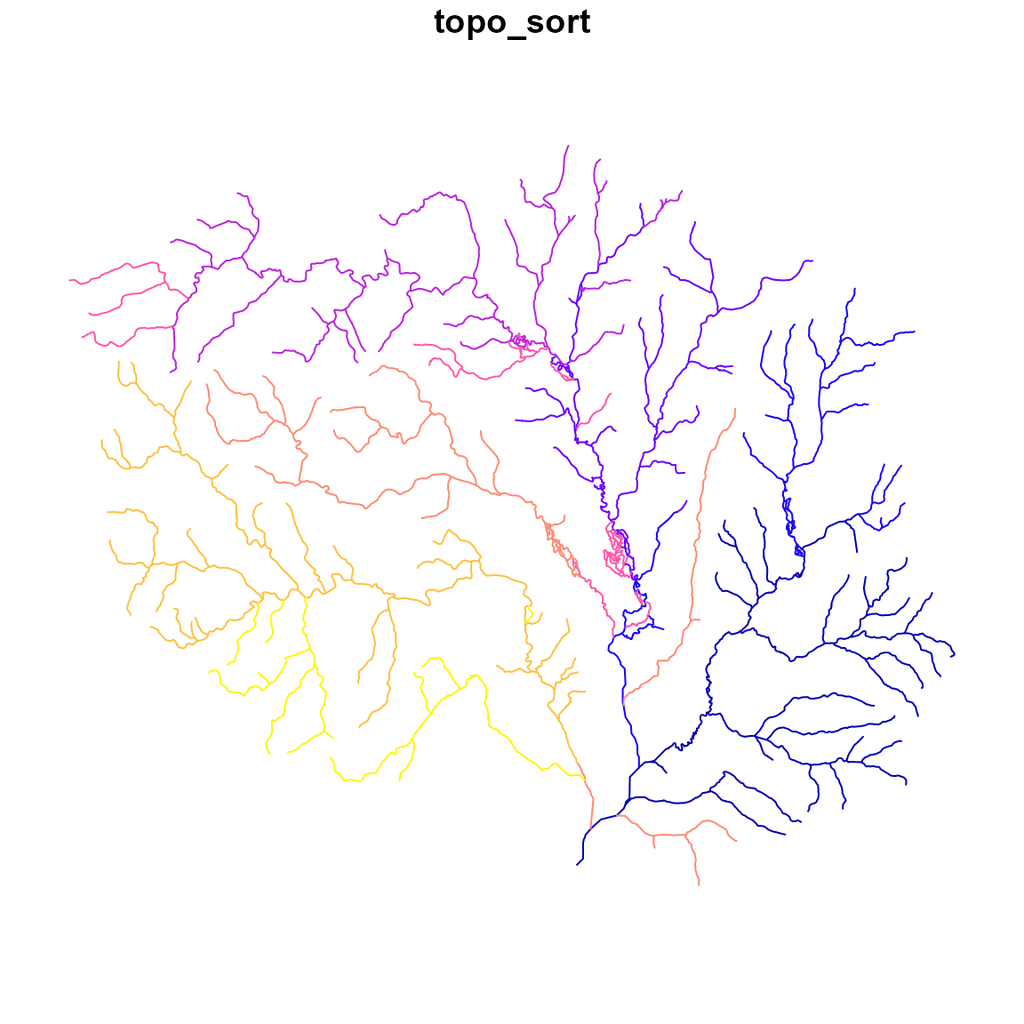

## Use case 2 · same network, three network representations

```r
# dual: flowlines-as-edges
x <- hy(flines)
# class(x): hy_node, hy...

# dendritic edge list (toid)
x_topo <- add_toids(x)
# class(x): hy_topo, hy...

# non-dendritic edge list
x_flow <- to_flownetwork(x)
# class(x): hy_flownetwork...
```

`hy_topo` drops the secondary path;

`hy_flownetwork` preserves it.

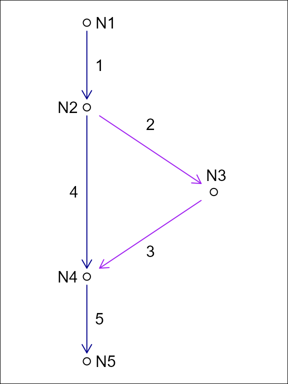

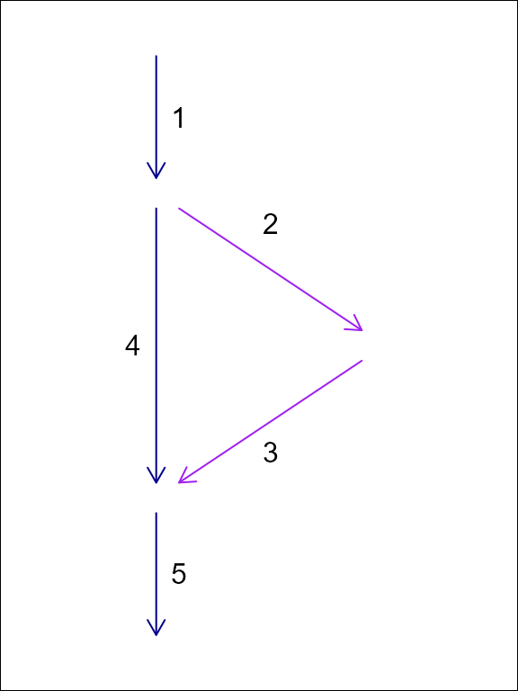

## Use case 3 · accumulation through diversions

**Total upstream**

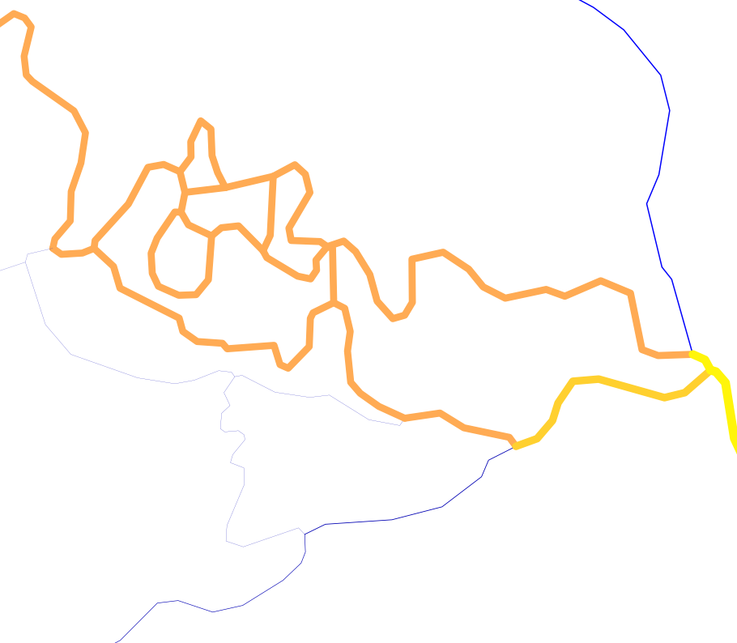

**Divergence-routed**

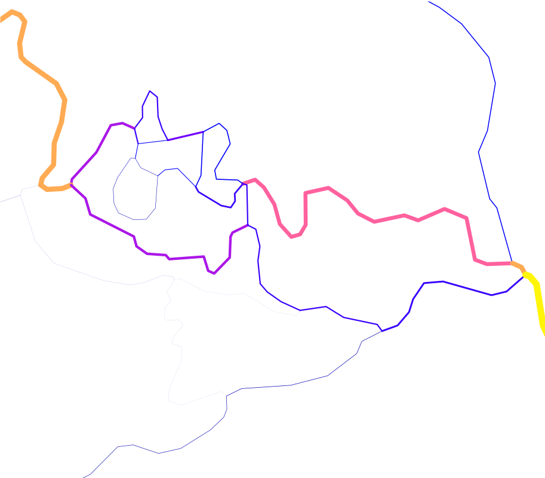

## Use case 4 · domain decomposition

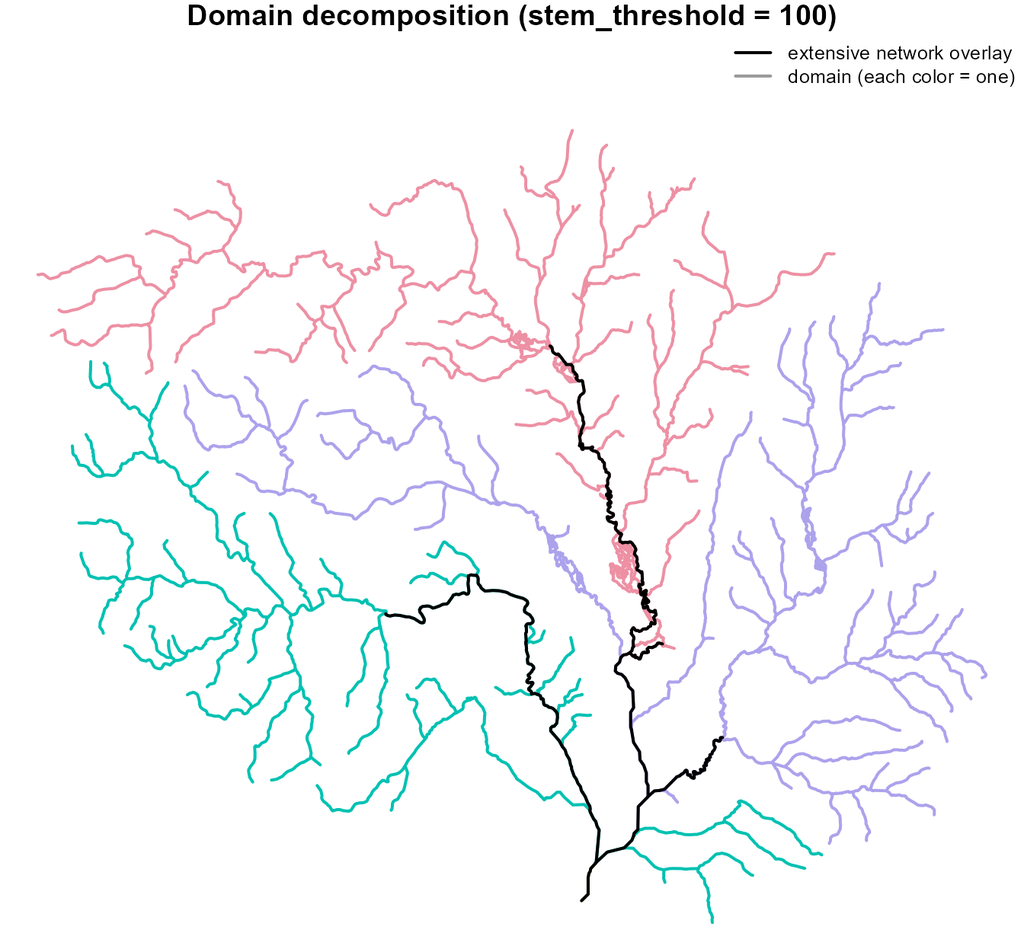

## Try it

```r
install.packages("hydroloom")
```

- **Docs** · https://doi-usgs.github.io/hydroloom/
- **Repo** · https://github.com/DOI-USGS/hydroloom

**References**

- Blodgett et al., 2024. Generating a reference flow network with improved connectivity to support durable data integration and reproducibility in the coterminous US *Environmental Modelling & Software.* https://doi.org/10.1016/j.envsoft.2023.105726

**Contact** · dblodgett@usgs.gov

### Questions?

[figure not shown]